# Syed_Imran_Saleem_DSBA_Project_EasyVisa_FullCode_v2.0

## Boosting - Model Building and Hyperparameter Tuning

### AdaBoost Classifier

```python
ab_classifier = AdaBoostClassifier(random_state=1) ## code to define AdaBoost Classifier with random state = 1
ab_classifier.fit(X_train, y_train) ## code to fit AdaBoost Classifier on the train data
```

```
AdaBoostClassifier(random_state=1)
```

#### Checking model performance on training set

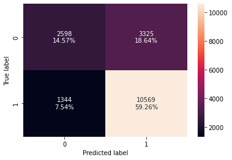

```python
confusion_matrix_sklearn(ab_classifier, X_train, y_train) ## code to create confusion matrix for train data
```

```python
ab_classifier_model_train_perf = model_performance_classification_sklearn(ab_classifier, X_train, y_train) ## code to check performance on train data
ab_classifier_model_train_perf
```

|  | Accuracy | Recall | Precision | F1 |
| --- | --- | --- | --- | --- |
| 0 | 0.738226 | 0.887182 | 0.760688 | 0.81908 |

#### Checking model performance on test set

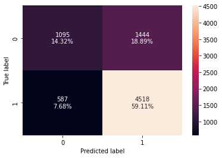

```python
confusion_matrix_sklearn(ab_classifier, X_test, y_test) ## code to create confusion matrix for test data
```

```python
ab_classifier_model_test_perf = model_performance_classification_sklearn(ab_classifier, X_test, y_test) ##  code to check performance for test data
ab_classifier_model_test_perf
```

|  | Accuracy | Recall | Precision | F1 |
| --- | --- | --- | --- | --- |
| 0 | 0.734301 | 0.885015 | 0.757799 | 0.816481 |

**Observations** Ada boost Classifier has decent results in which both Train and test results are comparable, f1 score (81.6%) is slightly low compared to previous model (random forest tuned - 82.09%)

However lets see if ada boost hypertuning helps to bring better results

### Hyperparameter Tuning - AdaBoost Classifier

```python
# Choose the type of classifier.
abc_tuned = AdaBoostClassifier(random_state=1)

# Grid of parameters to choose from
parameters = {
    # Let's try different max_depth for base_estimator
    "base_estimator": [
        DecisionTreeClassifier(max_depth=1, class_weight="balanced", random_state=1),
        DecisionTreeClassifier(max_depth=2, class_weight="balanced", random_state=1),
    ],
    "n_estimators": np.arange(80, 101, 10),
    "learning_rate": np.arange(0.1, 0.4, 0.1),
}

# Type of scoring used to compare parameter  combinations
acc_scorer = metrics.make_scorer(metrics.f1_score)

# Run the grid search
grid_obj = GridSearchCV(abc_tuned, parameters, scoring=acc_scorer, cv=5) ## code to run grid search with cv = 5
grid_obj = grid_obj.fit(X_train, y_train) ## code to fit the grid_obj on train data

# Set the clf to the best combination of parameters
abc_tuned = grid_obj.best_estimator_

# Fit the best algorithm to the data.
abc_tuned.fit(X_train, y_train)
```

```
AdaBoostClassifier(base_estimator=DecisionTreeClassifier(class_weight='balanced',
                                                         max_depth=1,
                                                         random_state=1),
                   learning_rate=0.1, n_estimators=100, random_state=1)
```

#### Checking model performance on training set

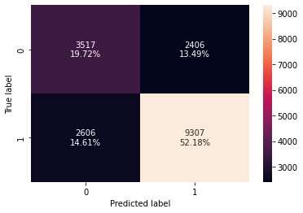

```python
confusion_matrix_sklearn(abc_tuned, X_train, y_train) ## code to create confusion matrix for train data on tuned estimator
```

```python
abc_tuned_model_train_perf = model_performance_classification_sklearn(abc_tuned, X_train, y_train) ## code to check performance for train data on tuned estimator
abc_tuned_model_train_perf
```

|  | Accuracy | Recall | Precision | F1 |
| --- | --- | --- | --- | --- |
| 0 | 0.718995 | 0.781247 | 0.794587 | 0.787861 |

#### Checking model performance on test set

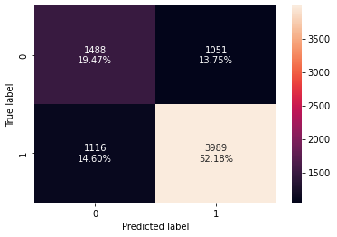

```python
confusion_matrix_sklearn(abc_tuned, X_test, y_test) ## code to create confusion matrix for test data on tuned estimator
```

```python
abc_tuned_model_test_perf = model_performance_classification_sklearn(abc_tuned, X_test, y_test) ##  code to check performance for test data on tuned estimator
abc_tuned_model_test_perf
```

|  | Accuracy | Recall | Precision | F1 |
| --- | --- | --- | --- | --- |
| 0 | 0.71651 | 0.781391 | 0.791468 | 0.786397 |

**Observations** Train and Test scores are comparable with tuned ada boost model; however f1 score is low just 78.63%

Lets try and evaluate GBM results

### Gradient Boosting Classifier

```python
gb_classifier = GradientBoostingClassifier(random_state=1) ##  code to define Gradient Boosting Classifier with random state = 1
gb_classifier.fit(X_train, y_train) ## code to fit Gradient Boosting Classifier on the train data
```

```
GradientBoostingClassifier(random_state=1)
```

#### Checking model performance on training set

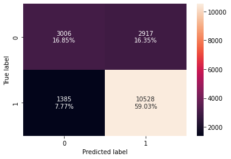

```python
confusion_matrix_sklearn(gb_classifier, X_train, y_train) ##  code to create confusion matrix for train data
```

```python
gb_classifier_model_train_perf = model_performance_classification_sklearn(gb_classifier, X_train, y_train) ##  code to check performance on train data
gb_classifier_model_train_perf
```

|  | Accuracy | Recall | Precision | F1 |
| --- | --- | --- | --- | --- |
| 0 | 0.758802 | 0.88374 | 0.783042 | 0.830349 |

#### Checking model performance on test set

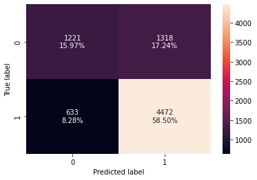

```python
confusion_matrix_sklearn(gb_classifier, X_test, y_test) ##  code to create confusion matrix for test data
```

```python
gb_classifier_model_test_perf = model_performance_classification_sklearn(gb_classifier, X_test, y_test) ## code to check performance for test data
gb_classifier_model_test_perf
```

|  | Accuracy | Recall | Precision | F1 |
| --- | --- | --- | --- | --- |
| 0 | 0.744767 | 0.876004 | 0.772366 | 0.820927 |

**Observations** GB classifier has decent results since both train and test results are comparable, f1 score on the test data is 82.09%

Lets see how GBM Hypertuning perform and their results

### Hyperparameter Tuning - Gradient Boosting Classifier

```python
# Choose the type of classifier.
gbc_tuned = GradientBoostingClassifier(
    init=AdaBoostClassifier(random_state=1), random_state=1
)

# Grid of parameters to choose from
parameters = {
    "n_estimators": [200, 250],
    "subsample": [0.9, 1],
    "max_features": [0.8, 0.9],
    "learning_rate": np.arange(0.1, 0.21, 0.1),
}

# Type of scoring used to compare parameter combinations
acc_scorer = metrics.make_scorer(metrics.f1_score)

# Run the grid search
grid_obj = GridSearchCV(gbc_tuned, parameters,scoring=acc_scorer, cv=5) ##  code to run grid search with cv = 5
grid_obj = grid_obj.fit(X_train, y_train) ##  code to fit the grid_obj on train data

# Set the clf to the best combination of parameters
gbc_tuned = grid_obj.best_estimator_

# Fit the best algorithm to the data.
gbc_tuned.fit(X_train, y_train)
```

```
GradientBoostingClassifier(init=AdaBoostClassifier(random_state=1),
                           max_features=0.8, n_estimators=200, random_state=1,
                           subsample=1)
```

#### Checking model performance on training set

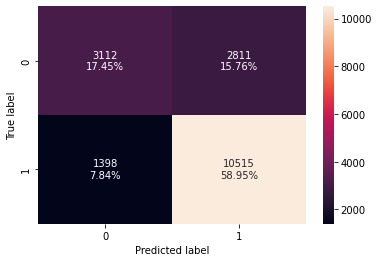

```python
confusion_matrix_sklearn(gbc_tuned, X_train, y_train) ##  code to create confusion matrix for train data on tuned estimator
```

```python
gbc_tuned_model_train_perf = model_performance_classification_sklearn(gbc_tuned, X_train, y_train) ##  code to check performance for train data on tuned estimator
gbc_tuned_model_train_perf
```

|  | Accuracy | Recall | Precision | F1 |
| --- | --- | --- | --- | --- |
| 0 | 0.764017 | 0.882649 | 0.789059 | 0.833234 |

#### Checking model performance on test set

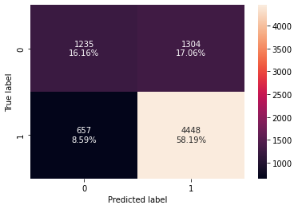

```python
confusion_matrix_sklearn(gbc_tuned, X_test, y_test) ##  code to create confusion matrix for test data on tuned estimator
```

```python
gbc_tuned_model_test_perf = model_performance_classification_sklearn(gbc_tuned, X_test, y_test) ##  code to check performance for test data on tuned estimator
gbc_tuned_model_test_perf
```

|  | Accuracy | Recall | Precision | F1 |
| --- | --- | --- | --- | --- |
| 0 | 0.743459 | 0.871303 | 0.773296 | 0.819379 |

**Observations** Seems again train and test results are comparable with Gradient boost hyper tuned model;

f1 score on the test data is slightly low around 81.93% compared to previous models

Lets see how XGBM performs and evaluate their results

### Note - You can choose **not to build** XGBoost if you have any installation issues

### XGBoost Classifier

```python
xgb_classifier = XGBClassifier(random_state=1, eval_metric="logloss") ##  code to define XGBoost Classifier with random state = 1 and eval_metric="logloss"
xgb_classifier.fit(X_train, y_train) ##  code to fit XGBoost Classifier on the train data
```

```
XGBClassifier(eval_metric='logloss', random_state=1)
```

#### Checking model performance on training set

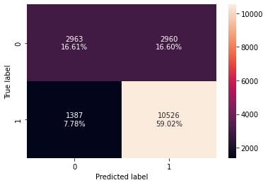

```python
confusion_matrix_sklearn(xgb_classifier, X_train, y_train) ##  code to create confusion matrix for train data
```

```python
xgb_classifier_model_train_perf = model_performance_classification_sklearn(xgb_classifier, X_train, y_train) ##  code to check performance on train data
xgb_classifier_model_train_perf
```

|  | Accuracy | Recall | Precision | F1 |
| --- | --- | --- | --- | --- |
| 0 | 0.756279 | 0.883573 | 0.780513 | 0.828852 |

#### Checking model performance on test set

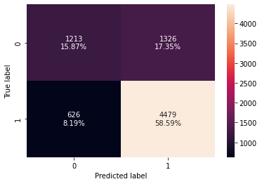

```python
confusion_matrix_sklearn(xgb_classifier, X_test, y_test) ##  code to create confusion matrix for test data
```

```python
xgb_classifier_model_test_perf = model_performance_classification_sklearn(xgb_classifier, X_test, y_test) ##  code to check performance for test data
xgb_classifier_model_test_perf
```

|  | Accuracy | Recall | Precision | F1 |
| --- | --- | --- | --- | --- |
| 0 | 0.744636 | 0.877375 | 0.771576 | 0.821082 |

**Observations**

1. Models are comparable (training and test)
2. f1 score on the test data is around 82.10% slightly better than previous models

Lets try XGBM hypertuning evaluation

### Hyperparameter Tuning - XGBoost Classifier

```python
# Choose the type of classifier.
xgb_tuned = XGBClassifier(random_state=1, eval_metric="logloss")

# Grid of parameters to choose from
parameters = {
    "n_estimators": np.arange(150, 250, 50),
    "scale_pos_weight": [1, 2],
    "subsample": [0.9, 1],
    "learning_rate": np.arange(0.1, 0.21, 0.1),
    "gamma": [3, 5],
    "colsample_bytree": [0.8, 0.9],
    "colsample_bylevel": [ 0.9, 1],
}

# Type of scoring used to compare parameter combinations
acc_scorer = metrics.make_scorer(metrics.f1_score)

# Run the grid search
grid_obj = GridSearchCV(xgb_tuned, parameters, scoring = acc_scorer, cv=5) ##  code to run grid search with cv = 5
grid_obj = grid_obj.fit(X_train, y_train) ##  code to fit the grid_obj on train data

# Set the clf to the best combination of parameters
xgb_tuned = grid_obj.best_estimator_

# Fit the best algorithm to the data.
xgb_tuned.fit(X_train, y_train)
```

```
XGBClassifier(colsample_bylevel=0.9, colsample_bytree=0.9,
              eval_metric='logloss', gamma=5, n_estimators=200, random_state=1)
```

#### Checking model performance on training set

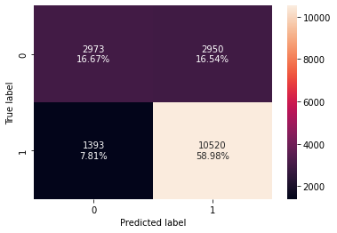

```python
confusion_matrix_sklearn(xgb_tuned, X_train, y_train) ##  code to create confusion matrix for train data on tuned estimator
```

```python
xgb_tuned_model_train_perf = model_performance_classification_sklearn(xgb_tuned, X_train, y_train) ##  code to check performance for train data on tuned estimator
xgb_tuned_model_train_perf
```

|  | Accuracy | Recall | Precision | F1 |
| --- | --- | --- | --- | --- |
| 0 | 0.756504 | 0.883069 | 0.780995 | 0.828901 |

#### Checking model performance on test set

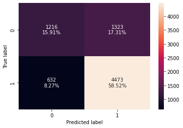

```python
confusion_matrix_sklearn(xgb_tuned, X_test, y_test) ##  code to create confusion matrix for test data on tuned estimator
```

```python
xgb_tuned_model_test_perf = model_performance_classification_sklearn(xgb_tuned, X_test, y_test) ## code to check performance for test data on tuned estimator
xgb_tuned_model_test_perf
```

|  | Accuracy | Recall | Precision | F1 |
| --- | --- | --- | --- | --- |
| 0 | 0.744244 | 0.8762 | 0.771739 | 0.820659 |

**Observations**

1. Training and Test data scores are comparable on XGB tuned model ;
2. f1 score is 82.0% (slightly lower than XGM without hyper tuning)

Lets see how Stacking performs

## Stacking Classifier

```python
estimators = [
    ("AdaBoost", ab_classifier),
    ("Gradient Boosting", gbc_tuned),
    ("Random Forest", rf_tuned),
]

final_estimator = xgb_tuned

stacking_classifier = StackingClassifier(estimators=estimators, final_estimator=final_estimator) ##  code to define Stacking Classifier

stacking_classifier.fit(X_train, y_train) ##  code to fit Stacking Classifier on the train data
```

```
StackingClassifier(estimators=[('AdaBoost', AdaBoostClassifier(random_state=1)),
                               ('Gradient Boosting',
                                GradientBoostingClassifier(init=AdaBoostClassifier(random_state=1),
                                                           max_features=0.8,
                                                           n_estimators=200,
                                                           random_state=1,
                                                           subsample=1)),
                               ('Random Forest',
                                RandomForestClassifier(max_depth=10,
                                                       max_features='sqrt',
                                                       min_samples_split=7,
                                                       n_estimators=20,
                                                       oob_score=True,
                                                       random_state=1))],
                   final_estimator=XGBClassifier(colsample_bylevel=0.9,
                                                 colsample_bytree=0.9,
                                                 eval_metric='logloss', gamma=5,
                                                 n_estimators=200,
                                                 random_state=1))
```

### Checking model performance on training set

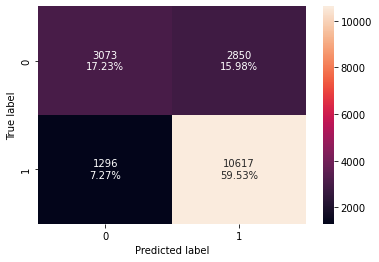

```python
confusion_matrix_sklearn(stacking_classifier, X_train, y_train) ##  code to create confusion matrix for train data
```

```python
stacking_classifier_model_train_perf = model_performance_classification_sklearn(stacking_classifier, X_train, y_train) ## Complete the code to check performance on train data
stacking_classifier_model_train_perf
```

|  | Accuracy | Recall | Precision | F1 |
| --- | --- | --- | --- | --- |
| 0 | 0.767549 | 0.891211 | 0.788372 | 0.836643 |

### Checking model performance on test set

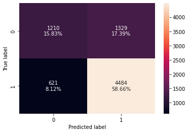

```python
confusion_matrix_sklearn(stacking_classifier, X_test, y_test) ## Complete the code to create confusion matrix for test data
```

```python
stacking_classifier_model_test_perf = model_performance_classification_sklearn(stacking_classifier, X_test, y_test) ## Complete the code to check performance for test data
stacking_classifier_model_test_perf
```

|  | Accuracy | Recall | Precision | F1 |
| --- | --- | --- | --- | --- |
| 0 | 0.744898 | 0.878355 | 0.771375 | 0.821396 |

**Observations**

1. Training and Test are almost comparable, Train f1 score is 83.7% and Test f1 score is 82.1%

Lets compare all models performance below and conclude the best one

## Model Performance Comparison and Final Model Selection

```python
# training performance comparison

models_train_comp_df = pd.concat(
    [
        decision_tree_perf_train.T,
        dtree_estimator_model_train_perf.T,
        bagging_classifier_model_train_perf.T,
        bagging_estimator_tuned_model_train_perf.T,
        rf_estimator_model_train_perf.T,
        rf_tuned_model_train_perf.T,
        ab_classifier_model_train_perf.T,
        abc_tuned_model_train_perf.T,
        gb_classifier_model_train_perf.T,
        gbc_tuned_model_train_perf.T,
        xgb_classifier_model_train_perf.T,
        xgb_tuned_model_train_perf.T,
        stacking_classifier_model_train_perf.T,
    ],
    axis=1,
)
models_train_comp_df.columns = [
    "Decision Tree",
    "Tuned Decision Tree",
    "Bagging Classifier",
    "Tuned Bagging Classifier",
    "Random Forest",
    "Tuned Random Forest",
    "Adaboost Classifier",
    "Tuned Adaboost Classifier",
    "Gradient Boost Classifier",
    "Tuned Gradient Boost Classifier",
    "XGBoost Classifier",
    "XGBoost Classifier Tuned",
    "Stacking Classifier",
]
print("Training performance comparison:")
models_train_comp_df
```

```
Training performance comparison:
```

|  | Decision Tree | Tuned Decision Tree | Bagging Classifier | Tuned Bagging Classifier | Random Forest | Tuned Random Forest | Adaboost Classifier | Tuned Adaboost Classifier | Gradient Boost Classifier | Tuned Gradient Boost Classifier | XGBoost Classifier | XGBoost Classifier Tuned | Stacking Classifier |
| --- | --- | --- | --- | --- | --- | --- | --- | --- | --- | --- | --- | --- | --- |
| Accuracy | 1.0 | 0.712548 | 0.985198 | 0.996187 | 0.999944 | 0.769119 | 0.738226 | 0.718995 | 0.758802 | 0.764017 | 0.756279 | 0.756504 | 0.767549 |
| Recall | 1.0 | 0.931923 | 0.985982 | 0.999916 | 0.999916 | 0.918660 | 0.887182 | 0.781247 | 0.883740 | 0.882649 | 0.883573 | 0.883069 | 0.891211 |
| Precision | 1.0 | 0.720067 | 0.991810 | 0.994407 | 1.000000 | 0.776556 | 0.760688 | 0.794587 | 0.783042 | 0.789059 | 0.780513 | 0.780995 | 0.788372 |
| F1 | 1.0 | 0.812411 | 0.988887 | 0.997154 | 0.999958 | 0.841652 | 0.819080 | 0.787861 | 0.830349 | 0.833234 | 0.828852 | 0.828901 | 0.836643 |

```python
# test performance comparison

models_test_comp_df = pd.concat(
    [
        decision_tree_perf_test.T,
        dtree_estimator_model_test_perf.T,
        bagging_classifier_model_test_perf.T,
        bagging_estimator_tuned_model_test_perf.T,
        rf_estimator_model_test_perf.T,
        rf_tuned_model_test_perf.T,
        ab_classifier_model_test_perf.T,
        abc_tuned_model_test_perf.T,
        gb_classifier_model_test_perf.T,
        gbc_tuned_model_test_perf.T,
        xgb_classifier_model_test_perf.T,
        xgb_tuned_model_test_perf.T,
        stacking_classifier_model_test_perf.T,
    ],
    axis=1,
)
models_test_comp_df.columns = [
    "Decision Tree",
    "Tuned Decision Tree",
    "Bagging Classifier",
    "Tuned Bagging Classifier",
    "Random Forest",
    "Tuned Random Forest",
    "Adaboost Classifier",
    "Tuned Adaboost Classifier",
    "Gradient Boost Classifier",
    "Tuned Gradient Boost Classifier",
    "XGBoost Classifier",
    "XGBoost Classifier Tuned",
    "Stacking Classifier",
]
print("Test performance comparison:")
models_test_comp_df ## Complete the code to check performance for test data
```

```
Test performance comparison:
```

|  | Decision Tree | Tuned Decision Tree | Bagging Classifier | Tuned Bagging Classifier | Random Forest | Tuned Random Forest | Adaboost Classifier | Tuned Adaboost Classifier | Gradient Boost Classifier | Tuned Gradient Boost Classifier | XGBoost Classifier | XGBoost Classifier Tuned | Stacking Classifier |
| --- | --- | --- | --- | --- | --- | --- | --- | --- | --- | --- | --- | --- | --- |
| Accuracy | 0.664835 | 0.706567 | 0.691523 | 0.724228 | 0.720827 | 0.738095 | 0.734301 | 0.716510 | 0.744767 | 0.743459 | 0.744636 | 0.744244 | 0.744898 |
| Recall | 0.742801 | 0.930852 | 0.764153 | 0.895397 | 0.832125 | 0.898923 | 0.885015 | 0.781391 | 0.876004 | 0.871303 | 0.877375 | 0.876200 | 0.878355 |
| Precision | 0.752232 | 0.715447 | 0.771711 | 0.743857 | 0.768869 | 0.755391 | 0.757799 | 0.791468 | 0.772366 | 0.773296 | 0.771576 | 0.771739 | 0.771375 |
| F1 | 0.747487 | 0.809058 | 0.767913 | 0.812622 | 0.799247 | 0.820930 | 0.816481 | 0.786397 | 0.820927 | 0.819379 | 0.821082 | 0.820659 | 0.821396 |

**Observations**

1. The stacking classifier is giving the highest f1-score on the test data (f1 score train : 0.837 ; test : 0.821)
2. However XGBoost Classifier is slightly better in terms of test and training data comparison (f1 score train : 0.829 ; test : 0.821)

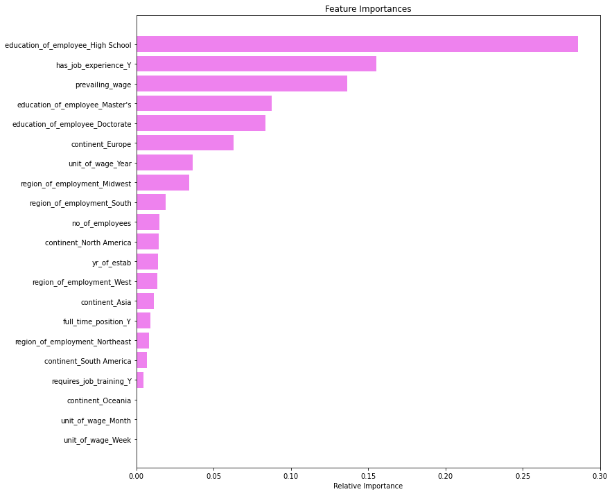

```python
feature_names = X_train.columns
importances = gb_classifier.feature_importances_
indices = np.argsort(importances)

plt.figure(figsize=(12, 12))
plt.title("Feature Importances")
plt.barh(range(len(indices)), importances[indices], color="violet", align="center")
plt.yticks(range(len(indices)), [feature_names[i] for i in indices])
plt.xlabel("Relative Importance")
plt.show()
```

**Observations**

1. Important features are education of employees who are high school; followed by experience ; prevailing wage ; education in masters ; education in doctorate

## Business Insights and Recommendations

1. Based on this analysis, I can say that the visa certified has the following features in comparison to the visa denials :
- (a) employees with high school education
- (b) employees with job experience
- (c) higher prevailing wage
- (d) employees with masters degree
- (e) employees with doctorate degree
- (f) companies based in Europe region
- (g) companies paying yearly unit of wage
1. From the model, its observed that the stacking classifier gave the highest f1-score on the test data (f1 score train : 0.837 ; test : 0.821); However XGBoost Classifier is slightly better in terms of test and training data comparison (f1 score train : 0.829 ; test : 0.821)
2. Once the desired performance is achieved from the model, it can be used to either certify / deny the visa.
3. This truly helps and benefits truly skilled employee gets their fair chance of visa certified instead of being denied and unskilled workers are denied for visa which helps to backfill the position / quota for truly skilled workers.
4. Given the visa system is fully exploited by many employers in an unethical manner by filing visas that makes unskilled workers getting visa certified and skilled workers getting visa denials, a good model is really required to understand various critical factors that makes system robust and helps employers filter the right employees to even qualify for visa filing.
5. This process not only helps employers file for their employees in a fair manner, but also helps employees educate themselves to stand competive in this technical market